# Week 8: Likelihood, Information, and Divergence

STAT 536 — Statistical Computing

Soumojit Das

Fall 2026

# Likelihood and Incomplete Data

## Where We Are

- Last week: Bayes’ rule turned a prior and a likelihood into a posterior for an unknown.
- This week and next: maximum likelihood when part of the data is missing, the EM algorithm.
- The E-step of EM is Bayes’ rule, applied to the missing data.
- On the way: Shannon’s measure of information, which explains why EM works and returns later in Bayesian computation.

## Probability and Likelihood

- The same expression $p(X \mid \theta)$ answers two questions.
- **Probability:** $\theta$ fixed, $X$ random. A coin with $\theta = 0.7$ gives 7 heads in 10 flips with probability $\binom{10}{7}(0.7)^7(0.3)^3 = 0.267$.
- **Likelihood:** $X$ fixed at what we observed, $\theta$ varies: $L(\theta; X) = p(X \mid \theta)$.
- **Question:** having seen 7 heads, which value do the data favor, $\theta = 0.7$ or $\theta = 0.3$?
- $L(0.7; X) = 0.267$ and $L(0.3; X) = 0.009$: the observed data are about 30 times as probable under $\theta = 0.7$ as under $\theta = 0.3$.

where $X$: the number of heads in 10 flips; $\theta$: the probability of heads; the semicolon in $L(\theta; X)$ separates the argument we optimize over from the fixed data.

## Likelihood Notation

| Symbol | Name | Meaning | What varies | What is fixed |
| --- | --- | --- | --- | --- |
| $p(X \mid \theta)$ | probability | probability of the data given the parameter | $X$ (random) | $\theta$ (known) |
| $L(\theta; X)$ | likelihood | support for the parameter given the data | $\theta$ (unknown) | $X$ (observed) |
| $\ell(\theta; X) = \log L(\theta; X)$ | log-likelihood | log of the likelihood | $\theta$ (unknown) | $X$ (observed) |

- Probability is used for prediction and simulation; likelihood for estimation, inference, and model fitting.
- Capital $L$ for the likelihood, script $\ell$ for its logarithm, never a plain $l$, which looks like 1 or I.
- Some texts write $L(\theta \mid X)$; same meaning.

## Why Logarithms

For independent data, $L(\theta; X) = \prod_i p(x_i \mid \theta)$ and $\ell(\theta; X) = \sum_i \log p(x_i \mid \theta)$.

| Products, $L$ | Sums, $\ell$ |
| --- | --- |
| a product of many small probabilities | a sum, with no numerical trouble |
| $(0.01)^{1000} = 10^{-2000}$ underflows: a computer cannot store it | $1000\log(0.01) \approx -4605$ |
| messy derivatives | clean derivatives |

- $\log$ is increasing, so $L$ and $\ell$ have the same maximizer, still called the maximum likelihood estimate.

where $x_i$: the $i$th observation.

## Example: Normal Data

- $x_1, \ldots, x_n \iid \Normal(\mu, \sigma^2)$:
  $$\ell(\mu, \sigma^2; X) = -\frac n2\log(2\pi) - \frac n2\log\sigma^2 - \frac{1}{2\sigma^2}\sum_{i=1}^n (x_i - \mu)^2$$
- Setting the two derivatives to zero: $\hat\mu = \bar x$ and $\hat\sigma^2 = \frac1n\sum_i (x_i - \bar x)^2$.

where $\mu$, $\sigma^2$: the mean and the variance; $n$: the sample size; $\bar x$: the sample mean.

## A Likelihood Method

- As we use it, EM is a likelihood method: $\theta$ is a fixed unknown constant, and we maximize $\ell(\theta; X)$.
- No prior on $\theta$, no posterior for $\theta$.
- The only conditional distribution of an unknown in EM is that of the missing data given the observed data, by Bayes’ rule.
- Same likelihood, two uses: the Bayesian puts $p(X \mid \theta)$ into Bayes’ rule; the frequentist maximizes it.

## Where Missing Data Arise

| Field | Incomplete information |
| --- | --- |
| Economics and finance | asset returns partially observed; default status unknown for some borrowers; customer types unobserved |
| Political science | survey non-response; hidden ideologies behind legislative votes; unobserved negotiations in coalition formation |
| Computer science | pixel labels unknown in image segmentation; missing ratings in recommender systems; hidden topics in documents |
| Statistics | component membership in mixture models; censored survival times; latent factors in factor analysis |

- The common thread: incomplete information makes direct maximum likelihood hard.

## Customer Segmentation

- An online retailer records, for each customer, the amount spent, the items purchased, and the visit frequency.
- **Goal:** customer segments for targeted marketing.
- The segment of each customer is not recorded.
- We need to estimate each segment’s characteristics, assign customers to segments, and handle the uncertainty in the assignments, all at once.
- We observe two continuous features, spending and visit frequency, for 150 simulated customers, 50 per segment; the segment labels are missing, and the data appear to cluster.

## Customer Segments

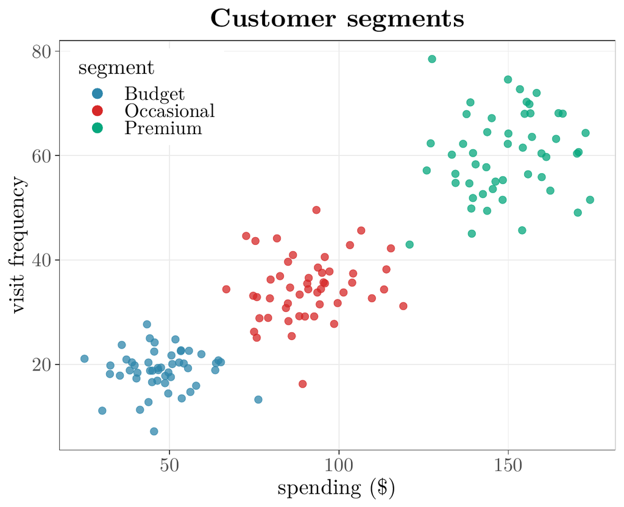

- Each point: one customer. Colors: the three segments.
- The data we have are the points without the colors.
- Observed data: the features $x_i$. Latent data: the segment labels $z_i$.

where $x_i$: the spending and visit frequency of customer $i$; $z_i$: its segment.

## The Missing-Data Problem

- **Observed data** $X = (x_1, \ldots, x_n)$: what we measure.
- **Latent data** $Z = (z_1, \ldots, z_n)$: what we wish we knew.
- **Complete data** $(X, Z)$.
- **Complete-data likelihood**, if we knew $Z$: $L_c(\theta; X, Z) = p(X, Z \mid \theta)$, often easy to maximize.
- **Observed-data likelihood**, what we have: $L(\theta; X) = p(X \mid \theta) = \int p(X, Z \mid \theta)\,dZ$, usually hard.

where the integral is a sum when $Z$ is discrete; $\ell_c = \log L_c$ and $\ell = \log L$.

## Why Direct Maximization Fails

$$\frac{\partial}{\partial\theta}\,\ell(\theta; X) = \frac{\int \frac{\partial}{\partial\theta}\, p(X, Z \mid \theta)\,dZ}{\int p(X, Z \mid \theta)\,dZ}$$

where $p(X, Z \mid \theta)$: the joint density of the observed and latent data; both integrals are over $Z$.

- The integral stays in the denominator.
- Setting the gradient to zero usually gives coupled equations with no closed-form solution.
- With a high-dimensional $Z$, even numerical integration is infeasible.
- **The idea of EM:** maximize a lower bound on $\ell$ that is easier to work with, and iterate.

# Jensen’s Inequality and a Lower Bound

## Convex Functions

- $f$ is **convex** if
  $$f(\lambda x + (1 - \lambda)y) \le \lambda f(x) + (1 - \lambda) f(y) \quad \text{for all } x, y \text{ and } \lambda \in [0, 1].$$
- The chord between two points of the graph lies above the graph.
- **Convex:** $x^2$, $e^x$, $|x|$, $\max(0, x)$.
- **Concave**, the inequality reversed: $\log x$.

where $\lambda$: the weight on $x$ in the average $\lambda x + (1 - \lambda)y$.

## A Convex Function and Its Chord

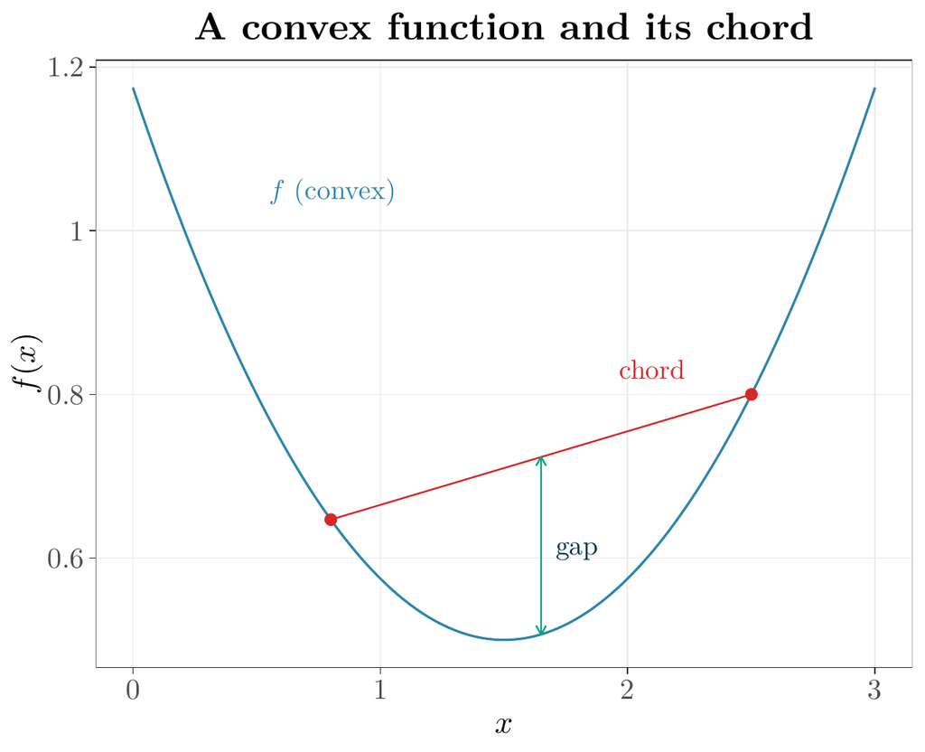

- Blue: the convex function $f(x) = 0.3(x - 1.5)^2 + 0.5$. Red: the chord between two points of its graph.
- Green: the gap at the midpoint, chord minus function, never negative for a convex $f$.

## Jensen’s Inequality

**Theorem (Jensen)**

If $f$ is convex, $f(\E[X]) \le \E[f(X)]$. If $f$ is concave, $f(\E[X]) \ge \E[f(X)]$. If $f$ is strictly convex or strictly concave, equality holds only when $X$ is constant.

where $X$: a random variable with a finite mean (positive, for the $\log$ question below).

- The function at the average is at most the average of the function, for a convex $f$.
- It is the definition of convexity, with the weights $\lambda$ and $1 - \lambda$ replaced by probabilities.
- **Question:** $\log$ is concave. Which is larger, $\log\E[X]$ or $\E[\log X]$?
- $\log\E[X] \ge \E[\log X]$. This gives the lower bound EM needs.

## A Lower Bound on the Log-Likelihood

For any distribution $q(Z)$ of the latent data, positive wherever $p(X, Z \mid \theta)$ is,
$$\ell(\theta; X) = \log\int \frac{p(X, Z \mid \theta)}{q(Z)}\,q(Z)\,dZ = \log\E_q\Bigl[\frac{p(X, Z \mid \theta)}{q(Z)}\Bigr] \ge \E_q\Bigl[\log\frac{p(X, Z \mid \theta)}{q(Z)}\Bigr] = \mathcal{L}(q, \theta).$$

where $p(X, Z \mid \theta)$: the joint density of the observed and latent data; $\E_q$: the expectation over $Z$ distributed as $q$.

- The inequality is Jensen’s, for the concave $\log$.
- $\mathcal{L}(q, \theta) = \E_q[\log p(X, Z \mid \theta)] - \E_q[\log q(Z)]$ is the **evidence lower bound** (ELBO).
- It holds for every $q$.

## When the Bound Is Tight

- Jensen’s inequality for the strictly concave $\log$ is an equality only when the random variable is constant: $p(X, Z \mid \theta)/q(Z) = c$.
- Then $q(Z) = p(X, Z \mid \theta)/c$, and since $q$ integrates to 1, $c = p(X \mid \theta)$.
- So $q(Z) = p(X, Z \mid \theta)/p(X \mid \theta) = p(Z \mid X, \theta)$, the posterior of the latent data.

**Key result**

The bound touches $\ell(\theta; X)$ exactly when $q$ is the posterior of $Z$ at $\theta$.

- For any other $q$, how far below $\ell$ is the bound? Measuring that gap means measuring how far $q$ is from the posterior: a question about information.

where $c$: a constant, free of $Z$; $p(Z \mid X, \theta)$: the conditional distribution of the latent data given the observed data.

# Information

## Shannon’s Question

- Claude Shannon, *A Mathematical Theory of Communication* (1948): how much information does a message carry, and how compactly can it be sent?
- His answer sets meaning aside: information is the reduction of uncertainty.
- A message that tells us what we already expected carries little information. A surprising one carries a lot.
- Surprise, entropy, cross-entropy, and the Kullback–Leibler divergence all measure information in this sense.

## Information as Surprise

- Three requirements for the information $I(p)$ of an event of probability $p$:
  - **Rare is informative:** $I(p)$ decreases as $p$ increases.
  - **Certain is uninformative:** $I(1) = 0$.
  - **Independent information adds:** $I(p_1 p_2) = I(p_1) + I(p_2)$.
- Up to the choice of unit, the only continuous function with these properties is
  $$I(p) = -\log p:$$
  the logarithm turns the product of probabilities of independent events into a sum of information.

where $p_1$, $p_2$: the probabilities of two independent events, so $p_1 p_2$ is the probability that both happen.

## Bits

- With $\log_2$ the unit is the **bit**, a word Shannon credits to John Tukey: $I(p) = -\log_2 p$.
- One fair coin flip: $-\log_2(1/2) = 1$ bit.
- One roll of a fair die: $\log_2 6 = 2.58$ bits. One card from a shuffled deck: $\log_2 52 = 5.70$ bits.
- Ten fair coin flips: $-\log_2(1/1024) = 10$ bits, one per flip: information adds.
- With the natural logarithm the unit is the **nat**: 1 nat $= 1/\log 2 \approx 1.44$ bits. Log-likelihoods are in nats.

## The Surprise Curve

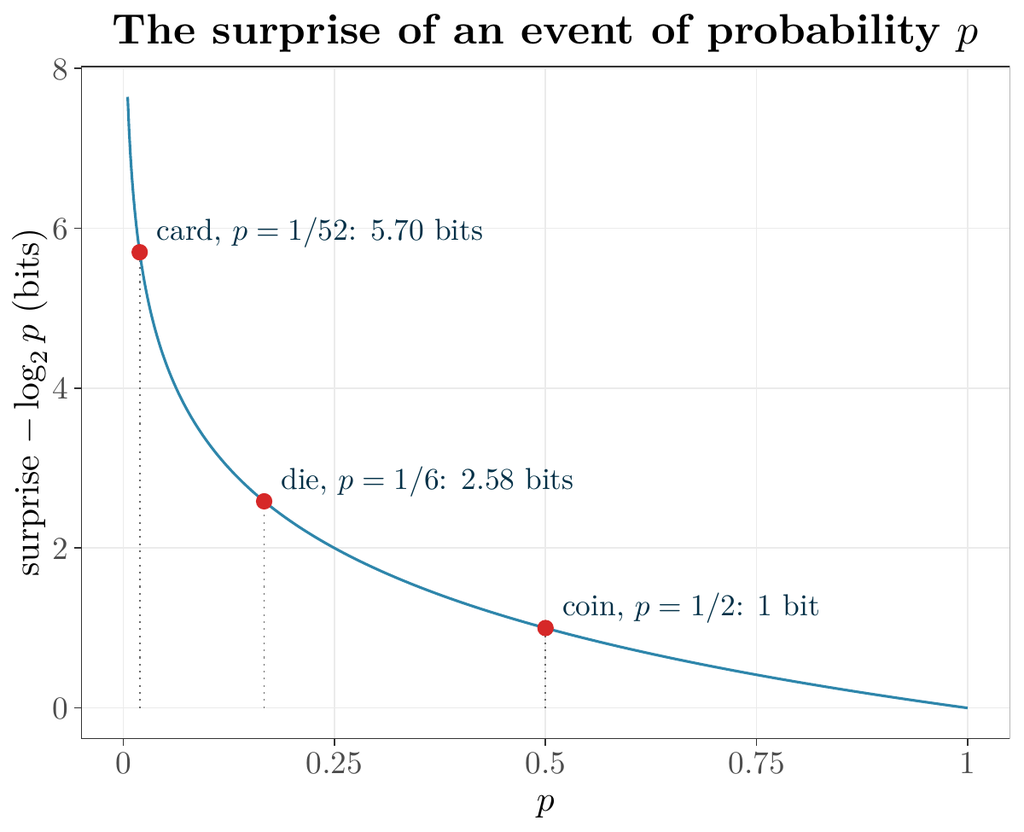

- The information $-\log_2 p$ of an event of probability $p$.
- Marked: a coin flip (1 bit), a die roll (2.58 bits), a card (5.70 bits).
- Zero at $p = 1$; it grows without bound as $p \to 0$.

## Entropy: Average Surprise

- Before we observe $X$, the information we expect to receive is its **entropy**:
  $$H(X) = \E[-\log_2 p(X)] = -\sum_x p(x)\log_2 p(x).$$
- The entropy is the average surprise of $X$, its uncertainty, in bits.
- A fair coin: 1 bit. A fair die: $\log_2 6 = 2.58$ bits. A certain outcome: 0 bits.
- An outcome with $p(x) = 0$ contributes 0, since $p\log p \to 0$ as $p \to 0$.

where $p(x)$: the probability that $X = x$.

## The Entropy of a Coin

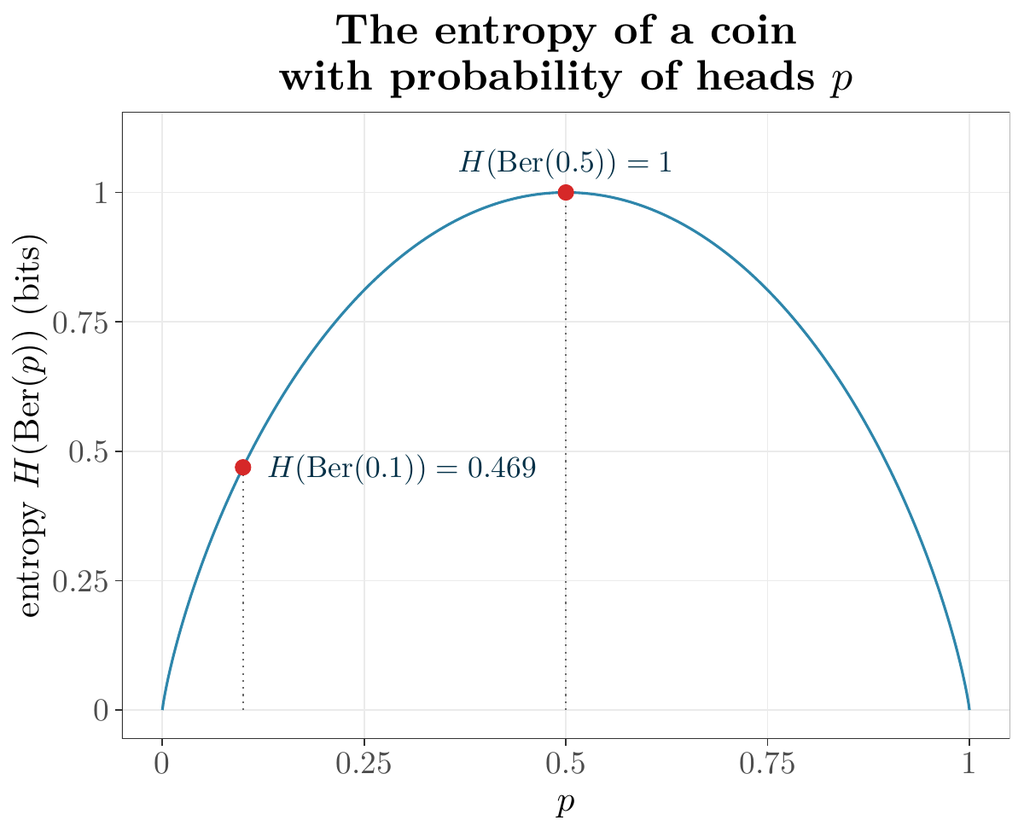

- $H(\Ber(p)) = -p\log_2 p - (1 - p)\log_2(1 - p)$: the entropy of a coin with probability of heads $p$.
- Largest at $p = 1/2$: 1 bit. At $p = 0.1$: 0.469 bits. Zero at $p = 0$ and $p = 1$.
- A biased coin is more predictable, so each flip tells us less.

## Low and High Entropy

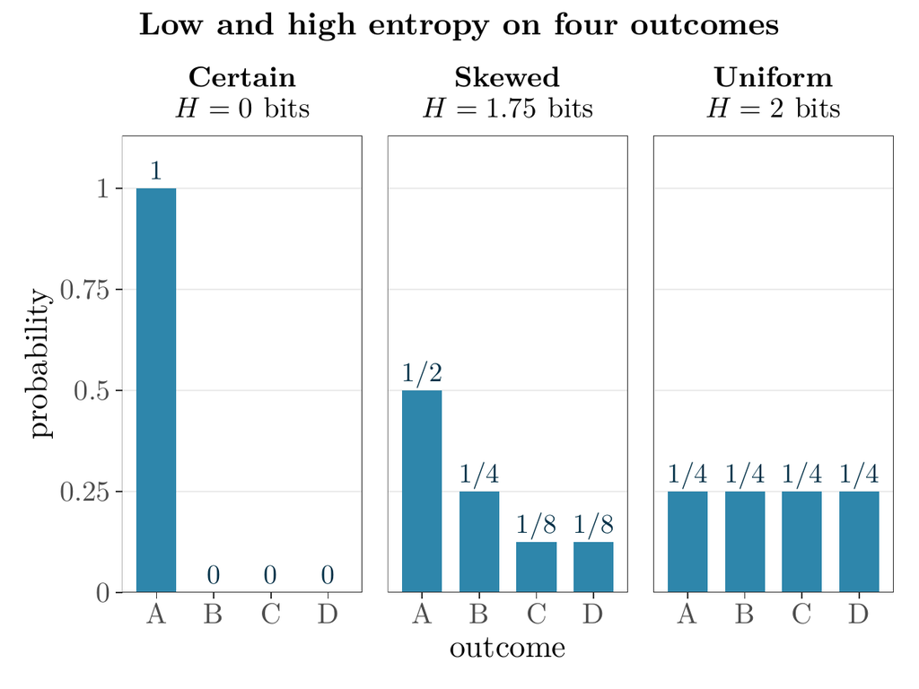

- Three distributions on four outcomes: certain, skewed $(1/2, 1/4, 1/8, 1/8)$, and uniform.
- Entropies 0, 1.75, and 2 bits.
- Spreading the probability out raises the entropy. On $K$ outcomes the uniform distribution has the most, $\log_2 K$.

## Twenty Questions

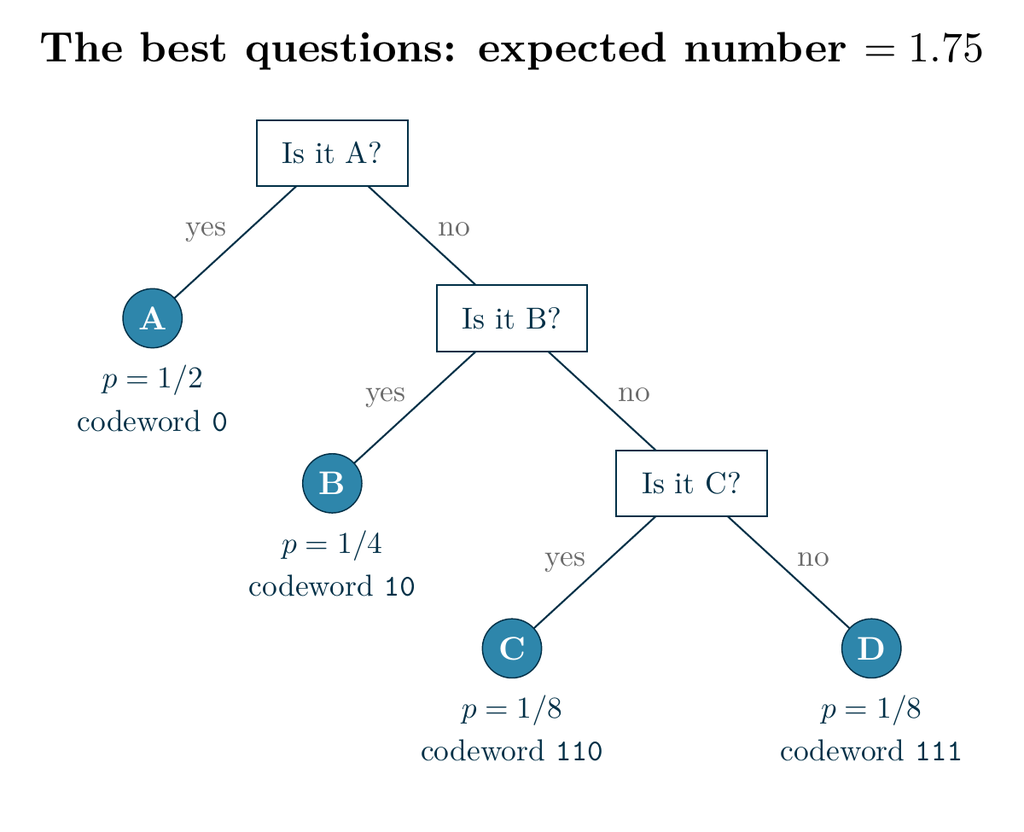

- Guess an outcome of $(1/2, 1/4, 1/8, 1/8)$ by yes/no questions. Ask about the likely outcomes first.
- Expected number of questions: $1 \cdot \tfrac12 + 2 \cdot \tfrac14 + 3 \cdot \tfrac18 + 3 \cdot \tfrac18 = 1.75$, the entropy.
- Entropy is the average number of yes/no questions the best strategy needs: exactly here, within one question in general.

## Codes

| Outcome | Probability | Codeword | Length | $-\log_2 p$ |
| --- | --- | --- | --- | --- |
| A | 1/2 | 0 | 1 | 1 |
| B | 1/4 | 10 | 2 | 2 |
| C | 1/8 | 110 | 3 | 3 |
| D | 1/8 | 111 | 3 | 3 |

- A code writes each outcome as a string of 0s and 1s. Here the codeword is the list of answers to the questions, yes $= 0$ and no $= 1$.
- No codeword begins another, a **prefix code**, so a stream of codewords decodes without separators.
- Short codewords for common outcomes, as in Morse code, where E is one dot and T one dash (Morse needs a pause between letters; a prefix code does not).
- Average length: $1.75$ bits, the entropy.

## Shannon’s Source Coding Theorem

**Theorem (Shannon, 1948)**

No prefix code uses fewer than $H(X)$ bits per outcome on average, and some prefix code uses fewer than $H(X) + 1$. Coding blocks of $n$ independent outcomes at once brings the average below $H(X) + 1/n$ bits per outcome.

- Entropy is the limit of lossless compression: it can be approached but not beaten.
- Huffman (1952) found the best prefix code for any distribution; his method is part of the compression in ZIP and PNG files.
- When every probability is a power of $1/2$, as in our example, the best code meets the entropy exactly.

where $H(X)$: the entropy of the outcome, in bits; prefix code: no codeword begins another.

## Using the Wrong Code

- Every prefix code has $\sum_x 2^{-l(x)} \le 1$ (Kraft’s inequality), so its lengths are $l(x) = -\log_2 q(x)$ for some $q$ with total at most 1: choosing a code is choosing a distribution.
- Outcomes come from $P$, but the code was built for $Q$: outcome $x$ gets a codeword of length $-\log_2 q(x)$.
- The average length is the **cross-entropy**
  $$H(P, Q) = -\sum_x p(x)\log_2 q(x) = \E_P[-\log_2 q(X)].$$
- For $P = (1/2, 1/4, 1/8, 1/8)$: the code built for $P$ averages 1.75 bits; the uniform code, 2 bits for every outcome, averages 2; the code built for $Q = (1/8, 1/8, 1/4, 1/2)$ averages 2.625.

where $l(x)$: the length of the codeword for $x$; $p$, $q$: the probabilities under $P$ and $Q$; $\E_P$: the expectation with $X$ distributed as $P$.

## Extra Bits

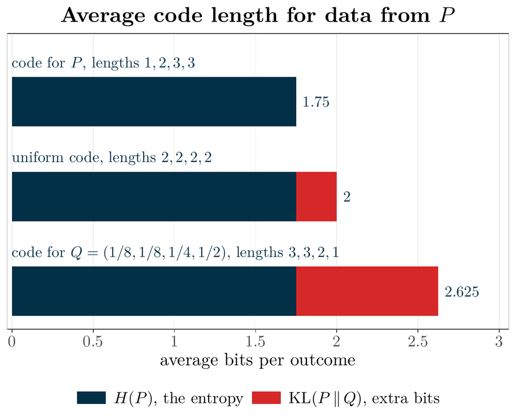

- Each bar: the average code length for data from $P = (1/2, 1/4, 1/8, 1/8)$ under one code.
- Dark: the entropy $H(P) = 1.75$ bits, which no prefix code beats. Red: the extra bits, 0, 0.25, and 0.875.
- The extra bits are the price of coding with the wrong distribution.

## Relative Entropy

$$\mathrm{KL}(P \,\|\, Q) = H(P, Q) - H(P) = \sum_x p(x)\log_2\frac{p(x)}{q(x)}$$

- The average number of extra bits paid for coding data from $P$ with a code built for $Q$.
- Zero when $Q = P$, and never negative (Gibbs’ inequality): no prefix code averages fewer bits on data from $P$ than the entropy $H(P)$.
- It compares two distributions, which is what the gap in EM’s bound needs.

where $H(P, Q)$: the cross-entropy; $H(P)$: the entropy of $P$; $p$, $q$: the probabilities under $P$ and $Q$.

## What Shannon Changed

- **Communication:** every noisy channel has a capacity; below it, error-correcting codes make transmission as reliable as we like. They run phones, Wi-Fi, CDs, and deep-space probes.
- **Compression:** entropy is the limit of lossless compression. Entropy coding is inside ZIP and PNG, and inside the lossy JPEG and MP3 formats.
- **Statistics:** Kullback and Leibler (1951) brought Shannon’s measure into statistics as a divergence between distributions; Akaike (1973) built AIC on it.
- **Machine learning:** logistic-regression and neural-network classifiers are trained by minimizing a cross-entropy, their negative log-likelihood; variational inference minimizes a KL divergence by maximizing an ELBO.

## Likelihood Is Code Length

- The negative log-likelihood $-\ell(\theta; X) = -\sum_i \log p(x_i \mid \theta)$ is the total surprise of the data under the model. For discrete data it is their code length, in nats, under a code built for the model.
- Within a model, maximum likelihood picks the parameter value whose code compresses the data best.
- If $P$ generates the data, then as $n$ grows
  $$-\frac1n\,\ell(\theta; X) \to H(P, Q_\theta) = H(P) + \mathrm{KL}(P \,\|\, Q_\theta).$$
- $H(P)$ does not involve $\theta$, so maximizing likelihood minimizes $\mathrm{KL}(P \,\|\, Q_\theta)$, the divergence of the model from $P$.

where $Q_\theta$: the model distribution, with density $q_\theta(x) = p(x \mid \theta)$; $x_1, \ldots, x_n$: independent draws from $P$; $H$ and $\mathrm{KL}$ in nats here, since $\ell$ uses the natural logarithm (for continuous data $H(P)$ is the differential entropy); the limit is the law of large numbers.

# The Kullback–Leibler Divergence

## Divergences

- We need to measure how different two distributions are: how far an approximate posterior is from the true one, how much information is lost using one distribution in place of another.
- A **divergence** $D(P \,\|\, Q)$ satisfies $D(P \,\|\, Q) \ge 0$, with $D(P \,\|\, Q) = 0$ if and only if $P = Q$.
- Unlike a distance, it need not be symmetric and need not satisfy the triangle inequality.

| Divergence | Definition | Properties |
| --- | --- | --- |
| total variation | $\frac12\int\lvert p(x) - q(x)\rvert\,dx$ | the largest difference in the probability of an event; symmetric, a distance |
| squared Hellinger | $\frac12\int\bigl(\sqrt{p(x)} - \sqrt{q(x)}\bigr)^2dx$ | symmetric, between 0 and 1; its square root is a distance |
| $\chi^2$ | $\int (p(x) - q(x))^2/q(x)\,dx$ | asymmetric; Pearson’s goodness-of-fit statistic is $n$ times it, with $p$ the observed proportions and $q$ the model’s |

where $p$, $q$: the densities of $P$ and $Q$.

## The KL Divergence

$$\mathrm{KL}(P \,\|\, Q) = \int p(x)\log\frac{p(x)}{q(x)}\,dx = \E_P\Bigl[\log\frac{p(X)}{q(X)}\Bigr]$$

where $p$, $q$: the densities of $P$ and $Q$; $\E_P$: the expectation with $X$ distributed as $P$; $\log$: the natural logarithm, so KL is in nats (divide by $\log 2$ for bits).

| Properties | Readings |
| --- | --- |
| $\mathrm{KL}(P \,\Vert\, Q) \ge 0$ | the expected log-ratio of the densities under $P$ |
| $\mathrm{KL}(P \,\Vert\, Q) = 0$ if and only if $P = Q$ | the information lost when $Q$ approximates $P$ |
| asymmetric, so not a distance | the extra nats (bits, with $\log_2$) needed to encode samples from $P$ with a code built for $Q$ |
| convex in the pair $(P, Q)$ |  |

- Also called the **relative entropy**. Direction matters: $\mathrm{KL}(P \,\|\, Q)$ averages under $P$.

## Gibbs’ Inequality

**Theorem (Gibbs’ inequality)**

$\mathrm{KL}(P \,\|\, Q) \ge 0$, with equality if and only if $P = Q$.

- By Jensen for the concave $\log$: $\mathrm{KL}(P \,\|\, Q) = -\E_P[\log(q/p)] \ge -\log\E_P[q/p] = -\log\int_{p > 0} q \ge -\log 1 = 0$.
- In coding terms: on data from $P$, a code built for $Q$ costs at least $H(P)$ bits per outcome, the cost of the code built for $P$.
- A consequence: with $Q$ uniform on $K$ outcomes, $\mathrm{KL}(P \,\|\, Q) = \log_2 K - H(P) \ge 0$ bits, so no distribution on $K$ outcomes has entropy above $\log_2 K$.

where $p$, $q$: the densities (or probabilities) of $P$ and $Q$; the integral runs over the values where $p > 0$.

## Two Examples

- **Two normals:** for $P = \Normal(\mu_1, \sigma_1^2)$ and $Q = \Normal(\mu_2, \sigma_2^2)$,
  $$\mathrm{KL}(P \,\|\, Q) = \log\frac{\sigma_2}{\sigma_1} + \frac{\sigma_1^2 + (\mu_1 - \mu_2)^2}{2\sigma_2^2} - \frac12.$$
- For the normals: write out $\log(p/q)$, take its expectation under $P$, and use $\E_P[X] = \mu_1$ and $\E_P[X^2] = \sigma_1^2 + \mu_1^2$.
- **Two Bernoullis:** for $P = \Ber(a)$ and $Q = \Ber(b)$, the binary KL divergence, common in information theory and machine learning,
  $$\mathrm{KL}(P \,\|\, Q) = a\log\frac{a}{b} + (1 - a)\log\frac{1 - a}{1 - b}.$$

where $\mu_1, \mu_2$: the means; $\sigma_1^2, \sigma_2^2$: the variances; $a$, $b$: the success probabilities; $p$, $q$: the densities of $P$ and $Q$.

## KL Divergence Between Two Normals

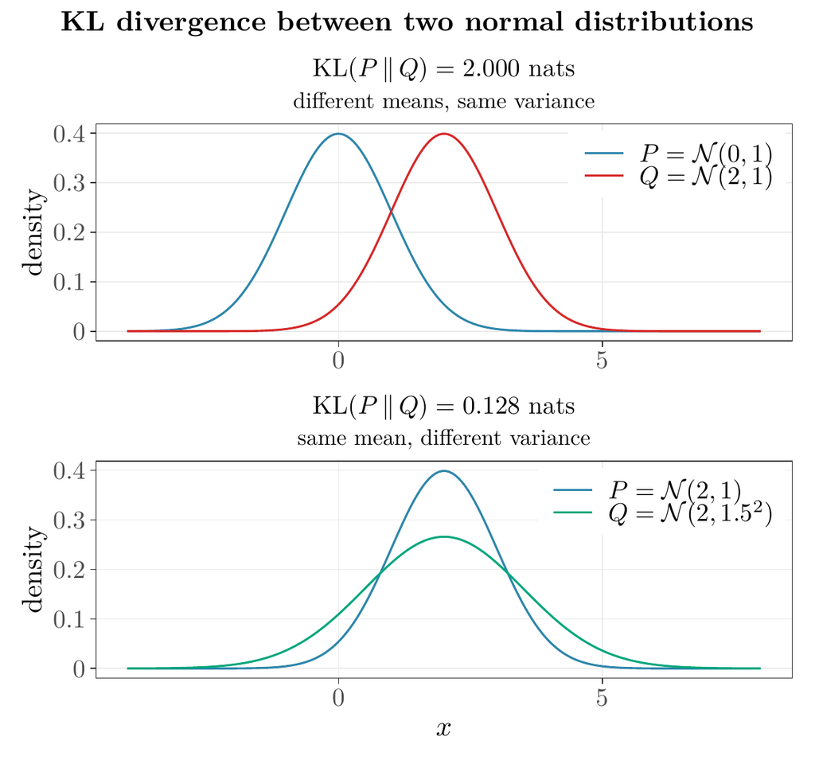

- Top: $P = \Normal(0, 1)$, $Q = \Normal(2, 1)$, different means, same variance. $\mathrm{KL}(P \,\|\, Q) = 2.000$ nats.
- Bottom: $P = \Normal(2, 1)$, $Q = \Normal(2, 1.5^2)$, same mean, different variances. $\mathrm{KL}(P \,\|\, Q) = 0.128$ nats, but $\mathrm{KL}(Q \,\|\, P) = 0.220$ nats.
- Never negative, and not symmetric.

where $\mathrm{KL}(P \,\|\, Q) = \E_P[\log p(X)/q(X)]$, with $p$, $q$ the densities of $P$, $Q$.

## KL Divergence in Statistical Inference

- **Model selection:** for a model $Q_\theta$ of the true $P$,
  $$\mathrm{KL}(P \,\|\, Q_\theta) = \E_P[\log p(X)] - \E_P[\log q_\theta(X)],$$
  so minimizing the divergence over $\theta$ maximizes the expected log-likelihood.
- **Variational inference:** approximate an intractable posterior $p(z \mid x)$ by the $q$ in a tractable family that minimizes $\mathrm{KL}\bigl(q \,\|\, p(\cdot \mid x)\bigr)$, the basis of variational Bayes and variational EM.

where $p$, $q_\theta$: the densities of $P$ and $Q_\theta$; $z$, $x$: the latent and the observed data.

## Back to EM’s Bound

$$\mathcal{L}(q, \theta) = \E_q[\log p(X, Z \mid \theta)] - \E_q[\log q(Z)] = \underbrace{\E_q[\log p(X, Z \mid \theta)]}_{\text{fit}} + \underbrace{H(q)}_{\text{entropy of } q}$$

- The ELBO is the expected log joint plus the entropy of $q$: fit rewards concentrating $q$ where the joint density is high, entropy rewards spreading it out.
- Remember our lower bound? The gap is exactly a KL divergence: $\ell(\theta; X) - \mathcal{L}(q, \theta) = \mathrm{KL}\bigl(q(Z) \,\|\, p(Z \mid X, \theta)\bigr)$.
- So Gibbs’ inequality is the bound: $\ell(\theta; X) \ge \mathcal{L}(q, \theta)$, with equality exactly when $q = p(Z \mid X, \theta)$. The posterior is the $q$ that balances fit and entropy best.

where $H(q) = -\E_q[\log q(Z)]$: the entropy of $q$, in nats (for a continuous $Z$, the differential entropy $-\int q(z)\log q(z)\,dz$, which can be negative).

## Notation

| Symbol | Meaning |
| --- | --- |
| $X$, $Z$ | observed data, latent data |
| $p(X, Z \mid \theta)$ | joint density of observed and latent data |
| $p(Z \mid X, \theta)$ | posterior of the latent data |
| $L(\theta; X)$, $\ell(\theta; X)$ | likelihood, log-likelihood |
| $L_c$, $\ell_c$ | complete-data likelihood, log-likelihood |
| $q(Z)$, $\E_q$ | a distribution for $Z$, expectation under it |
| $\mathcal{L}(q, \theta)$ | evidence lower bound (ELBO) |

| Symbol | Meaning |
| --- | --- |
| $I(p) = -\log_2 p$ | information of an event of probability $p$ |
| $H(X)$, $H(P)$ | entropy |
| $H(P, Q)$ | cross-entropy |
| $\mathrm{KL}(P \,\Vert\, Q)$ | Kullback–Leibler divergence |
| $Q_\theta$, $q_\theta$ | model distribution, its density |
| bit, nat | units of $\log_2$ and $\log$; 1 nat $= 1/\log 2$ bits |

## Punchlines, and What Comes Next

- With latent data the log-likelihood is the log of an integral, $\ell(\theta; X) = \log\int p(X, Z \mid \theta)\,dZ$, and setting its gradient to zero rarely has a closed-form solution.
- Jensen’s inequality gives a lower bound for every $q$, $\ell(\theta; X) \ge \mathcal{L}(q, \theta)$, tight exactly when $q$ is the posterior $p(Z \mid X, \theta)$.
- Information is surprise, $-\log p$. Entropy is average surprise and the limit of lossless compression.
- The KL divergence is the extra length paid for coding with the wrong distribution, and Gibbs’ inequality says it is never negative.
- In the limit, maximizing the likelihood minimizes $\mathrm{KL}(P \,\|\, Q_\theta)$, and the gap in EM’s bound is a KL divergence.

The log of an integral is what makes these likelihoods hard. Jensen’s inequality trades it for an average of logs, at the price of a gap, and information theory says exactly what the gap is.

Next: the identity $\ell(\theta; X) = \mathcal{L}(q, \theta) + \mathrm{KL}\bigl(q(Z) \,\|\, p(Z \mid X, \theta)\bigr)$ and the EM algorithm built on it: the E-step sets $q$ to the posterior, the M-step maximizes the bound over $\theta$.

# Entropy and Energy

## Maximum Entropy

- On $K$ outcomes, the uniform distribution has the largest entropy, $\log_2 K$: it assumes nothing beyond the list of outcomes.
- Among densities with a given variance $\sigma^2$, the normal has the largest differential entropy, $\frac12\log_2(2\pi e\sigma^2)$ bits.
- **The maximum entropy principle** (Jaynes, 1957): given what we know, as constraints, choose the distribution with the largest entropy. It adds no information we do not have.

where the differential entropy of a density $p$ is $-\int p(x)\log_2 p(x)\,dx$; $\sigma^2$: the variance.

## Surprise Is Energy

- Write any positive density as $p(x) = e^{-E(x)}/\mathcal{Z}$, with $\mathcal{Z} = \int e^{-E(x)}\,dx$. Then $-\log p(x) = E(x) + \log\mathcal{Z}$: surprise is energy, up to a constant.
- Low energy, high probability; high energy, rare.
- In physics, $p_T(x) = e^{-E(x)/T}/\mathcal{Z}_T$ is the **Boltzmann distribution** at temperature $T$. Among all distributions with the same average energy as $p_T$, it has the largest entropy.
- Hamiltonian Monte Carlo writes the posterior as $\pi(\theta \mid X) \propto e^{-U(\theta)}$, with potential energy $U(\theta) = -\log[L(\theta; X)\,\pi(\theta)]$.

where $E(x)$: the energy of state $x$; $\mathcal{Z}$, $\mathcal{Z}_T$: the normalizing constants; $T > 0$: the temperature, in units where Boltzmann’s constant is 1; $L(\theta; X)$: the likelihood; $\pi(\theta)$: the prior.

## Temperature

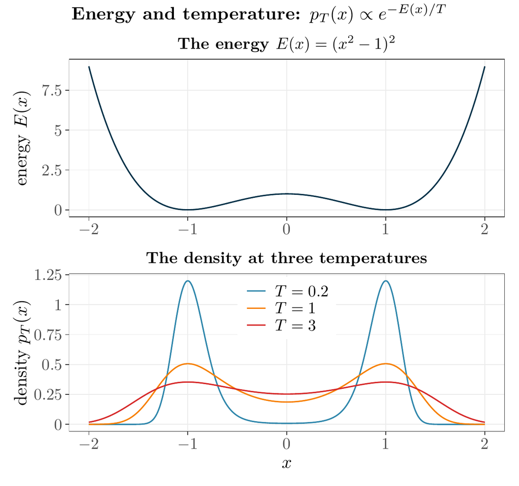

- Top: a double-well energy $E(x) = (x^2 - 1)^2$. Bottom: the Boltzmann densities at $T = 0.2$, 1, and 3.
- Low temperature: the mass piles into the two wells. High temperature: it spreads out, and the entropy rises (0.55, 1.58, 1.88 bits at $T = 0.2$, 1, and 3).
- Simulated annealing and tempered MCMC turn this dial.

where $p_T(x) \propto e^{-E(x)/T}$; the entropies are differential entropies.